# Optimal Treatment Analysis

## Outcome Variable

**Outcome Variable:** ever_stunted

## Predictor Variables

**Intervention Variable:** brthmon

**Adjustment Set:**

unadjusted

## Stratifying Variables

The analysis was stratified on these variable(s):

- agecat
- studyid
- country

## Data Summary

| agecat | studyid | country | brthmon | ever_stunted | n_cell | n |
| --- | --- | --- | --- | --- | --- | --- |
| 0-24 months | ki0047075b-MAL-ED | BANGLADESH | 1 | 0 | 8 | 265 |
| 0-24 months | ki0047075b-MAL-ED | BANGLADESH | 1 | 1 | 13 | 265 |
| 0-24 months | ki0047075b-MAL-ED | BANGLADESH | 2 | 0 | 7 | 265 |
| 0-24 months | ki0047075b-MAL-ED | BANGLADESH | 2 | 1 | 18 | 265 |
| 0-24 months | ki0047075b-MAL-ED | BANGLADESH | 3 | 0 | 8 | 265 |
| 0-24 months | ki0047075b-MAL-ED | BANGLADESH | 3 | 1 | 17 | 265 |
| 0-24 months | ki0047075b-MAL-ED | BANGLADESH | 4 | 0 | 12 | 265 |
| 0-24 months | ki0047075b-MAL-ED | BANGLADESH | 4 | 1 | 10 | 265 |
| 0-24 months | ki0047075b-MAL-ED | BANGLADESH | 5 | 0 | 5 | 265 |
| 0-24 months | ki0047075b-MAL-ED | BANGLADESH | 5 | 1 | 17 | 265 |
| 0-24 months | ki0047075b-MAL-ED | BANGLADESH | 6 | 0 | 5 | 265 |
| 0-24 months | ki0047075b-MAL-ED | BANGLADESH | 6 | 1 | 6 | 265 |
| 0-24 months | ki0047075b-MAL-ED | BANGLADESH | 7 | 0 | 7 | 265 |
| 0-24 months | ki0047075b-MAL-ED | BANGLADESH | 7 | 1 | 13 | 265 |
| 0-24 months | ki0047075b-MAL-ED | BANGLADESH | 8 | 0 | 10 | 265 |
| 0-24 months | ki0047075b-MAL-ED | BANGLADESH | 8 | 1 | 16 | 265 |
| 0-24 months | ki0047075b-MAL-ED | BANGLADESH | 9 | 0 | 10 | 265 |
| 0-24 months | ki0047075b-MAL-ED | BANGLADESH | 9 | 1 | 13 | 265 |
| 0-24 months | ki0047075b-MAL-ED | BANGLADESH | 10 | 0 | 13 | 265 |
| 0-24 months | ki0047075b-MAL-ED | BANGLADESH | 10 | 1 | 12 | 265 |
| 0-24 months | ki0047075b-MAL-ED | BANGLADESH | 11 | 0 | 8 | 265 |
| 0-24 months | ki0047075b-MAL-ED | BANGLADESH | 11 | 1 | 9 | 265 |
| 0-24 months | ki0047075b-MAL-ED | BANGLADESH | 12 | 0 | 11 | 265 |
| 0-24 months | ki0047075b-MAL-ED | BANGLADESH | 12 | 1 | 17 | 265 |
| 0-24 months | ki0047075b-MAL-ED | BRAZIL | 1 | 0 | 12 | 233 |
| 0-24 months | ki0047075b-MAL-ED | BRAZIL | 1 | 1 | 3 | 233 |
| 0-24 months | ki0047075b-MAL-ED | BRAZIL | 2 | 0 | 18 | 233 |
| 0-24 months | ki0047075b-MAL-ED | BRAZIL | 2 | 1 | 7 | 233 |
| 0-24 months | ki0047075b-MAL-ED | BRAZIL | 3 | 0 | 16 | 233 |
| 0-24 months | ki0047075b-MAL-ED | BRAZIL | 3 | 1 | 4 | 233 |

[output cut: 2034 more lines]

The following strata were considered:

- agecat: 0-24 months, studyid: ki0047075b-MAL-ED, country: BANGLADESH
- agecat: 0-24 months, studyid: ki0047075b-MAL-ED, country: BRAZIL
- agecat: 0-24 months, studyid: ki0047075b-MAL-ED, country: INDIA
- agecat: 0-24 months, studyid: ki0047075b-MAL-ED, country: NEPAL
- agecat: 0-24 months, studyid: ki0047075b-MAL-ED, country: PERU
- agecat: 0-24 months, studyid: ki0047075b-MAL-ED, country: SOUTH AFRICA
- agecat: 0-24 months, studyid: ki0047075b-MAL-ED, country: TANZANIA, UNITED REPUBLIC OF
- agecat: 0-24 months, studyid: ki1000108-CMC-V-BCS-2002, country: INDIA
- agecat: 0-24 months, studyid: ki1000108-IRC, country: INDIA
- agecat: 0-24 months, studyid: ki1000109-EE, country: PAKISTAN
- agecat: 0-24 months, studyid: ki1000109-ResPak, country: PAKISTAN
- agecat: 0-24 months, studyid: ki1000304b-SAS-CompFeed, country: INDIA
- agecat: 0-24 months, studyid: ki1000304b-SAS-FoodSuppl, country: INDIA
- agecat: 0-24 months, studyid: ki1017093-NIH-Birth, country: BANGLADESH
- agecat: 0-24 months, studyid: ki1066203-TanzaniaChild2, country: TANZANIA, UNITED REPUBLIC OF
- agecat: 0-24 months, studyid: ki1101329-Keneba, country: GAMBIA
- agecat: 0-24 months, studyid: ki1112895-Guatemala BSC, country: GUATEMALA
- agecat: 0-24 months, studyid: ki1112895-iLiNS-Zinc, country: BURKINA FASO
- agecat: 0-24 months, studyid: ki1113344-GMS-Nepal, country: NEPAL
- agecat: 0-24 months, studyid: ki1114097-CMIN, country: BANGLADESH
- agecat: 0-24 months, studyid: ki1114097-CMIN, country: BRAZIL
- agecat: 0-24 months, studyid: ki1114097-CMIN, country: GUINEA-BISSAU
- agecat: 0-24 months, studyid: ki1114097-CMIN, country: PERU
- agecat: 0-24 months, studyid: ki1114097-CONTENT, country: PERU
- agecat: 0-24 months, studyid: ki1119695-PROBIT, country: BELARUS
- agecat: 0-24 months, studyid: ki1126311-ZVITAMBO, country: ZIMBABWE
- agecat: 0-24 months, studyid: ki1148112-LCNI-5, country: MALAWI
- agecat: 0-24 months, studyid: kiGH5241-JiVitA-3, country: BANGLADESH
- agecat: 0-24 months, studyid: kiGH5241-JiVitA-4, country: BANGLADESH
- agecat: 0-6 months, studyid: ki0047075b-MAL-ED, country: BANGLADESH
- agecat: 0-6 months, studyid: ki0047075b-MAL-ED, country: BRAZIL
- agecat: 0-6 months, studyid: ki0047075b-MAL-ED, country: INDIA
- agecat: 0-6 months, studyid: ki0047075b-MAL-ED, country: NEPAL
- agecat: 0-6 months, studyid: ki0047075b-MAL-ED, country: PERU
- agecat: 0-6 months, studyid: ki0047075b-MAL-ED, country: SOUTH AFRICA
- agecat: 0-6 months, studyid: ki0047075b-MAL-ED, country: TANZANIA, UNITED REPUBLIC OF
- agecat: 0-6 months, studyid: ki1000108-CMC-V-BCS-2002, country: INDIA
- agecat: 0-6 months, studyid: ki1000108-IRC, country: INDIA
- agecat: 0-6 months, studyid: ki1000109-EE, country: PAKISTAN
- agecat: 0-6 months, studyid: ki1000109-ResPak, country: PAKISTAN
- agecat: 0-6 months, studyid: ki1000304b-SAS-CompFeed, country: INDIA
- agecat: 0-6 months, studyid: ki1000304b-SAS-FoodSuppl, country: INDIA
- agecat: 0-6 months, studyid: ki1017093-NIH-Birth, country: BANGLADESH
- agecat: 0-6 months, studyid: ki1066203-TanzaniaChild2, country: TANZANIA, UNITED REPUBLIC OF
- agecat: 0-6 months, studyid: ki1101329-Keneba, country: GAMBIA
- agecat: 0-6 months, studyid: ki1112895-Guatemala BSC, country: GUATEMALA
- agecat: 0-6 months, studyid: ki1113344-GMS-Nepal, country: NEPAL
- agecat: 0-6 months, studyid: ki1114097-CMIN, country: BANGLADESH
- agecat: 0-6 months, studyid: ki1114097-CMIN, country: BRAZIL
- agecat: 0-6 months, studyid: ki1114097-CMIN, country: GUINEA-BISSAU
- agecat: 0-6 months, studyid: ki1114097-CMIN, country: PERU
- agecat: 0-6 months, studyid: ki1114097-CONTENT, country: PERU
- agecat: 0-6 months, studyid: ki1119695-PROBIT, country: BELARUS
- agecat: 0-6 months, studyid: ki1126311-ZVITAMBO, country: ZIMBABWE
- agecat: 0-6 months, studyid: ki1148112-LCNI-5, country: MALAWI
- agecat: 0-6 months, studyid: kiGH5241-JiVitA-3, country: BANGLADESH
- agecat: 0-6 months, studyid: kiGH5241-JiVitA-4, country: BANGLADESH
- agecat: 6-24 months, studyid: ki0047075b-MAL-ED, country: BANGLADESH
- agecat: 6-24 months, studyid: ki0047075b-MAL-ED, country: BRAZIL
- agecat: 6-24 months, studyid: ki0047075b-MAL-ED, country: INDIA
- agecat: 6-24 months, studyid: ki0047075b-MAL-ED, country: NEPAL
- agecat: 6-24 months, studyid: ki0047075b-MAL-ED, country: PERU
- agecat: 6-24 months, studyid: ki0047075b-MAL-ED, country: SOUTH AFRICA
- agecat: 6-24 months, studyid: ki0047075b-MAL-ED, country: TANZANIA, UNITED REPUBLIC OF
- agecat: 6-24 months, studyid: ki1000108-CMC-V-BCS-2002, country: INDIA
- agecat: 6-24 months, studyid: ki1000108-IRC, country: INDIA
- agecat: 6-24 months, studyid: ki1000109-EE, country: PAKISTAN
- agecat: 6-24 months, studyid: ki1000109-ResPak, country: PAKISTAN
- agecat: 6-24 months, studyid: ki1000304b-SAS-CompFeed, country: INDIA
- agecat: 6-24 months, studyid: ki1000304b-SAS-FoodSuppl, country: INDIA
- agecat: 6-24 months, studyid: ki1017093-NIH-Birth, country: BANGLADESH
- agecat: 6-24 months, studyid: ki1066203-TanzaniaChild2, country: TANZANIA, UNITED REPUBLIC OF
- agecat: 6-24 months, studyid: ki1101329-Keneba, country: GAMBIA
- agecat: 6-24 months, studyid: ki1112895-Guatemala BSC, country: GUATEMALA
- agecat: 6-24 months, studyid: ki1112895-iLiNS-Zinc, country: BURKINA FASO
- agecat: 6-24 months, studyid: ki1113344-GMS-Nepal, country: NEPAL
- agecat: 6-24 months, studyid: ki1114097-CMIN, country: BANGLADESH
- agecat: 6-24 months, studyid: ki1114097-CMIN, country: BRAZIL
- agecat: 6-24 months, studyid: ki1114097-CMIN, country: GUINEA-BISSAU
- agecat: 6-24 months, studyid: ki1114097-CMIN, country: PERU
- agecat: 6-24 months, studyid: ki1114097-CONTENT, country: PERU
- agecat: 6-24 months, studyid: ki1119695-PROBIT, country: BELARUS
- agecat: 6-24 months, studyid: ki1126311-ZVITAMBO, country: ZIMBABWE
- agecat: 6-24 months, studyid: ki1148112-LCNI-5, country: MALAWI
- agecat: 6-24 months, studyid: kiGH5241-JiVitA-3, country: BANGLADESH
- agecat: 6-24 months, studyid: kiGH5241-JiVitA-4, country: BANGLADESH

### Dropped Strata

Some strata were dropped due to rare outcomes:

- agecat: 0-24 months, studyid: ki0047075b-MAL-ED, country: BRAZIL
- agecat: 0-24 months, studyid: ki0047075b-MAL-ED, country: INDIA
- agecat: 0-24 months, studyid: ki0047075b-MAL-ED, country: NEPAL
- agecat: 0-24 months, studyid: ki0047075b-MAL-ED, country: SOUTH AFRICA
- agecat: 0-24 months, studyid: ki0047075b-MAL-ED, country: TANZANIA, UNITED REPUBLIC OF
- agecat: 0-24 months, studyid: ki1000108-CMC-V-BCS-2002, country: INDIA
- agecat: 0-24 months, studyid: ki1000108-IRC, country: INDIA
- agecat: 0-24 months, studyid: ki1000109-EE, country: PAKISTAN
- agecat: 0-24 months, studyid: ki1000109-ResPak, country: PAKISTAN
- agecat: 0-24 months, studyid: ki1000304b-SAS-FoodSuppl, country: INDIA
- agecat: 0-24 months, studyid: ki1112895-Guatemala BSC, country: GUATEMALA
- agecat: 0-24 months, studyid: ki1113344-GMS-Nepal, country: NEPAL
- agecat: 0-24 months, studyid: ki1114097-CMIN, country: BANGLADESH
- agecat: 0-24 months, studyid: ki1114097-CMIN, country: BRAZIL
- agecat: 0-24 months, studyid: ki1114097-CONTENT, country: PERU
- agecat: 0-24 months, studyid: kiGH5241-JiVitA-4, country: BANGLADESH
- agecat: 0-6 months, studyid: ki0047075b-MAL-ED, country: BANGLADESH
- agecat: 0-6 months, studyid: ki0047075b-MAL-ED, country: BRAZIL
- agecat: 0-6 months, studyid: ki0047075b-MAL-ED, country: INDIA
- agecat: 0-6 months, studyid: ki0047075b-MAL-ED, country: NEPAL
- agecat: 0-6 months, studyid: ki0047075b-MAL-ED, country: PERU
- agecat: 0-6 months, studyid: ki0047075b-MAL-ED, country: SOUTH AFRICA
- agecat: 0-6 months, studyid: ki0047075b-MAL-ED, country: TANZANIA, UNITED REPUBLIC OF
- agecat: 0-6 months, studyid: ki1000109-EE, country: PAKISTAN
- agecat: 0-6 months, studyid: ki1000109-ResPak, country: PAKISTAN
- agecat: 0-6 months, studyid: ki1000304b-SAS-FoodSuppl, country: INDIA
- agecat: 0-6 months, studyid: ki1112895-Guatemala BSC, country: GUATEMALA
- agecat: 0-6 months, studyid: ki1113344-GMS-Nepal, country: NEPAL
- agecat: 0-6 months, studyid: ki1114097-CMIN, country: BANGLADESH
- agecat: 0-6 months, studyid: ki1114097-CMIN, country: BRAZIL
- agecat: 0-6 months, studyid: ki1114097-CMIN, country: GUINEA-BISSAU
- agecat: 0-6 months, studyid: ki1114097-CMIN, country: PERU
- agecat: 0-6 months, studyid: ki1114097-CONTENT, country: PERU
- agecat: 0-6 months, studyid: ki1148112-LCNI-5, country: MALAWI
- agecat: 0-6 months, studyid: kiGH5241-JiVitA-4, country: BANGLADESH
- agecat: 6-24 months, studyid: ki0047075b-MAL-ED, country: BANGLADESH
- agecat: 6-24 months, studyid: ki0047075b-MAL-ED, country: BRAZIL
- agecat: 6-24 months, studyid: ki0047075b-MAL-ED, country: INDIA
- agecat: 6-24 months, studyid: ki0047075b-MAL-ED, country: NEPAL
- agecat: 6-24 months, studyid: ki0047075b-MAL-ED, country: PERU
- agecat: 6-24 months, studyid: ki0047075b-MAL-ED, country: SOUTH AFRICA
- agecat: 6-24 months, studyid: ki0047075b-MAL-ED, country: TANZANIA, UNITED REPUBLIC OF
- agecat: 6-24 months, studyid: ki1000108-CMC-V-BCS-2002, country: INDIA
- agecat: 6-24 months, studyid: ki1000108-IRC, country: INDIA
- agecat: 6-24 months, studyid: ki1000109-EE, country: PAKISTAN
- agecat: 6-24 months, studyid: ki1000109-ResPak, country: PAKISTAN
- agecat: 6-24 months, studyid: ki1000304b-SAS-FoodSuppl, country: INDIA
- agecat: 6-24 months, studyid: ki1112895-Guatemala BSC, country: GUATEMALA
- agecat: 6-24 months, studyid: ki1113344-GMS-Nepal, country: NEPAL
- agecat: 6-24 months, studyid: ki1114097-CMIN, country: BANGLADESH
- agecat: 6-24 months, studyid: ki1114097-CMIN, country: BRAZIL
- agecat: 6-24 months, studyid: ki1114097-CONTENT, country: PERU
- agecat: 6-24 months, studyid: kiGH5241-JiVitA-4, country: BANGLADESH

## Methods Detail

We’re interested in the causal parameters $E[Y_a]$ for all values of $a \in \mathcal{A}$. These parameters represent the mean outcome if, possibly contrary to fact, we intervened to set all units to have $A=a$. Under the randomization and positivity assumptions, these are identified by the statistical parameters $\psi_a=E_W[E_{Y|A,W}(Y|A=a,W)]$. In addition, we’re interested in the mean of $Y$, $E[Y]$ under no intervention (the observed mean). We will estimate these parameters by using SuperLearner to fit the relevant likelihood factors – $E_{Y|A,W}(Y|A=a,W)$ and $p(A=a|W)$, and then updating our likelihood fit using a joint TMLE.

For unadjusted analyses ($W=\{\}$), initial likelihoods were estimated using Lrnr_glm to estimate the simple $E(Y|A)$ and Lrnr_mean to estimate $p(A)$. For adjusted analyses, a small library containing Lrnr_glmnet, Lrnr_xgboost, and Lrnr_mean was used.

Having estimated these parameters, we will then use the delta method to estimate relative risks and attributable risks relative to a prespecified baseline level of $A$.

# Results Detail

## Results Plots

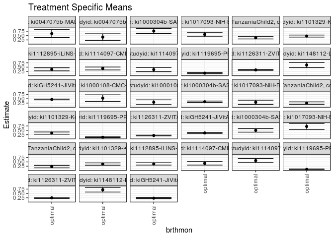

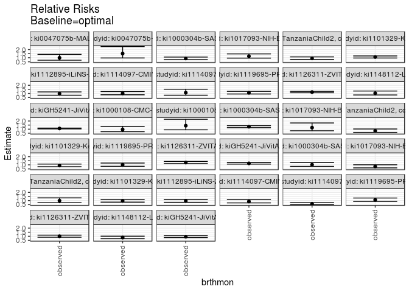

## Results Table

### Parameter: TSM

| agecat | studyid | country | intervention_level | baseline_level | estimate | ci_lower | ci_upper |
| --- | --- | --- | --- | --- | --- | --- | --- |
| 0-24 months | ki0047075b-MAL-ED | BANGLADESH | optimal | NA | 0.6124657 | 0.3856086 | 0.8393228 |
| 0-24 months | ki0047075b-MAL-ED | PERU | optimal | NA | 0.4096144 | 0.2189107 | 0.6003180 |
| 0-24 months | ki1000304b-SAS-CompFeed | INDIA | optimal | NA | 0.7625794 | 0.6273548 | 0.8978040 |
| 0-24 months | ki1017093-NIH-Birth | BANGLADESH | optimal | NA | 0.5615196 | 0.4338230 | 0.6892162 |
| 0-24 months | ki1066203-TanzaniaChild2 | TANZANIA, UNITED REPUBLIC OF | optimal | NA | 0.3730424 | 0.3060131 | 0.4400717 |
| 0-24 months | ki1101329-Keneba | GAMBIA | optimal | NA | 0.4726216 | 0.4140827 | 0.5311604 |
| 0-24 months | ki1112895-iLiNS-Zinc | BURKINA FASO | optimal | NA | 0.3759234 | 0.2868336 | 0.4650133 |
| 0-24 months | ki1114097-CMIN | GUINEA-BISSAU | optimal | NA | 0.4223616 | 0.3371416 | 0.5075816 |
| 0-24 months | ki1114097-CMIN | PERU | optimal | NA | 0.3604277 | 0.2380928 | 0.4827627 |
| 0-24 months | ki1119695-PROBIT | BELARUS | optimal | NA | 0.1549353 | 0.1251020 | 0.1847687 |
| 0-24 months | ki1126311-ZVITAMBO | ZIMBABWE | optimal | NA | 0.3397708 | 0.3140630 | 0.3654786 |
| 0-24 months | ki1148112-LCNI-5 | MALAWI | optimal | NA | 0.6205977 | 0.4713219 | 0.7698734 |
| 0-24 months | kiGH5241-JiVitA-3 | BANGLADESH | optimal | NA | 0.4567142 | 0.4332309 | 0.4801975 |
| 0-6 months | ki1000108-CMC-V-BCS-2002 | INDIA | optimal | NA | 0.5336419 | 0.3438541 | 0.7234297 |
| 0-6 months | ki1000108-IRC | INDIA | optimal | NA | 0.2984709 | 0.1609781 | 0.4359638 |
| 0-6 months | ki1000304b-SAS-CompFeed | INDIA | optimal | NA | 0.3277474 | 0.2872545 | 0.3682404 |
| 0-6 months | ki1017093-NIH-Birth | BANGLADESH | optimal | NA | 0.2952416 | 0.1735183 | 0.4169648 |
| 0-6 months | ki1066203-TanzaniaChild2 | TANZANIA, UNITED REPUBLIC OF | optimal | NA | 0.2489888 | 0.1796393 | 0.3183383 |
| 0-6 months | ki1101329-Keneba | GAMBIA | optimal | NA | 0.3396598 | 0.2764946 | 0.4028250 |
| 0-6 months | ki1119695-PROBIT | BELARUS | optimal | NA | 0.0993811 | 0.0748771 | 0.1238851 |
| 0-6 months | ki1126311-ZVITAMBO | ZIMBABWE | optimal | NA | 0.2015937 | 0.1798030 | 0.2233844 |
| 0-6 months | kiGH5241-JiVitA-3 | BANGLADESH | optimal | NA | 0.3477512 | 0.3195510 | 0.3759513 |
| 6-24 months | ki1000304b-SAS-CompFeed | INDIA | optimal | NA | 0.4953599 | 0.3944225 | 0.5962973 |
| 6-24 months | ki1017093-NIH-Birth | BANGLADESH | optimal | NA | 0.7217583 | 0.5498834 | 0.8936331 |
| 6-24 months | ki1066203-TanzaniaChild2 | TANZANIA, UNITED REPUBLIC OF | optimal | NA | 0.2295787 | 0.1575100 | 0.3016475 |
| 6-24 months | ki1101329-Keneba | GAMBIA | optimal | NA | 0.3768266 | 0.3105811 | 0.4430720 |
| 6-24 months | ki1112895-iLiNS-Zinc | BURKINA FASO | optimal | NA | 0.3831609 | 0.3173245 | 0.4489973 |
| 6-24 months | ki1114097-CMIN | GUINEA-BISSAU | optimal | NA | 0.4167238 | 0.3166109 | 0.5168366 |
| 6-24 months | ki1114097-CMIN | PERU | optimal | NA | 0.5753400 | 0.4551568 | 0.6955233 |
| 6-24 months | ki1119695-PROBIT | BELARUS | optimal | NA | 0.0709817 | 0.0490881 | 0.0928752 |
| 6-24 months | ki1126311-ZVITAMBO | ZIMBABWE | optimal | NA | 0.2468041 | 0.2131878 | 0.2804204 |
| 6-24 months | ki1148112-LCNI-5 | MALAWI | optimal | NA | 0.7153376 | 0.5803853 | 0.8502898 |
| 6-24 months | kiGH5241-JiVitA-3 | BANGLADESH | optimal | NA | 0.2296976 | 0.1992802 | 0.2601150 |

### Parameter: E(Y)

| agecat | studyid | country | intervention_level | baseline_level | estimate | ci_lower | ci_upper |
| --- | --- | --- | --- | --- | --- | --- | --- |
| 0-24 months | ki0047075b-MAL-ED | BANGLADESH | observed | NA | 0.6075472 | 0.5486452 | 0.6664491 |
| 0-24 months | ki0047075b-MAL-ED | PERU | observed | NA | 0.6204620 | 0.5657315 | 0.6751926 |
| 0-24 months | ki1000304b-SAS-CompFeed | INDIA | observed | NA | 0.6914547 | 0.6510509 | 0.7318584 |
| 0-24 months | ki1017093-NIH-Birth | BANGLADESH | observed | NA | 0.6645469 | 0.6276196 | 0.7014742 |
| 0-24 months | ki1066203-TanzaniaChild2 | TANZANIA, UNITED REPUBLIC OF | observed | NA | 0.3459933 | 0.3269422 | 0.3650444 |
| 0-24 months | ki1101329-Keneba | GAMBIA | observed | NA | 0.5125214 | 0.4943731 | 0.5306698 |
| 0-24 months | ki1112895-iLiNS-Zinc | BURKINA FASO | observed | NA | 0.3623277 | 0.3130786 | 0.4115769 |
| 0-24 months | ki1114097-CMIN | GUINEA-BISSAU | observed | NA | 0.4286662 | 0.4036720 | 0.4536605 |
| 0-24 months | ki1114097-CMIN | PERU | observed | NA | 0.3928956 | 0.3614728 | 0.4243183 |
| 0-24 months | ki1119695-PROBIT | BELARUS | observed | NA | 0.1674854 | 0.1488048 | 0.1861659 |
| 0-24 months | ki1126311-ZVITAMBO | ZIMBABWE | observed | NA | 0.3966461 | 0.3885633 | 0.4047288 |
| 0-24 months | ki1148112-LCNI-5 | MALAWI | observed | NA | 0.6369048 | 0.6043650 | 0.6694445 |
| 0-24 months | kiGH5241-JiVitA-3 | BANGLADESH | observed | NA | 0.4937950 | 0.4859633 | 0.5016266 |
| 0-6 months | ki1000108-CMC-V-BCS-2002 | INDIA | observed | NA | 0.5108696 | 0.4597270 | 0.5620121 |
| 0-6 months | ki1000108-IRC | INDIA | observed | NA | 0.4243902 | 0.3764905 | 0.4722900 |
| 0-6 months | ki1000304b-SAS-CompFeed | INDIA | observed | NA | 0.4254902 | 0.3977202 | 0.4532601 |
| 0-6 months | ki1017093-NIH-Birth | BANGLADESH | observed | NA | 0.3497615 | 0.3124631 | 0.3870600 |
| 0-6 months | ki1066203-TanzaniaChild2 | TANZANIA, UNITED REPUBLIC OF | observed | NA | 0.1949082 | 0.1790434 | 0.2107729 |
| 0-6 months | ki1101329-Keneba | GAMBIA | observed | NA | 0.3123732 | 0.2940736 | 0.3306728 |
| 0-6 months | ki1119695-PROBIT | BELARUS | observed | NA | 0.0995087 | 0.0864641 | 0.1125533 |
| 0-6 months | ki1126311-ZVITAMBO | ZIMBABWE | observed | NA | 0.2579888 | 0.2507541 | 0.2652234 |
| 0-6 months | kiGH5241-JiVitA-3 | BANGLADESH | observed | NA | 0.4107840 | 0.4033446 | 0.4182233 |
| 6-24 months | ki1000304b-SAS-CompFeed | INDIA | observed | NA | 0.5030750 | 0.4588491 | 0.5473009 |
| 6-24 months | ki1017093-NIH-Birth | BANGLADESH | observed | NA | 0.5739130 | 0.5216565 | 0.6261696 |
| 6-24 months | ki1066203-TanzaniaChild2 | TANZANIA, UNITED REPUBLIC OF | observed | NA | 0.2259675 | 0.2054816 | 0.2464534 |
| 6-24 months | ki1101329-Keneba | GAMBIA | observed | NA | 0.3589489 | 0.3380095 | 0.3798884 |
| 6-24 months | ki1112895-iLiNS-Zinc | BURKINA FASO | observed | NA | 0.3623277 | 0.3130786 | 0.4115769 |
| 6-24 months | ki1114097-CMIN | GUINEA-BISSAU | observed | NA | 0.3714710 | 0.3456477 | 0.3972943 |
| 6-24 months | ki1114097-CMIN | PERU | observed | NA | 0.3450439 | 0.3120195 | 0.3780683 |
| 6-24 months | ki1119695-PROBIT | BELARUS | observed | NA | 0.0768510 | 0.0628857 | 0.0908164 |
| 6-24 months | ki1126311-ZVITAMBO | ZIMBABWE | observed | NA | 0.2459470 | 0.2364841 | 0.2554098 |
| 6-24 months | ki1148112-LCNI-5 | MALAWI | observed | NA | 0.6000000 | 0.5644377 | 0.6355623 |
| 6-24 months | kiGH5241-JiVitA-3 | BANGLADESH | observed | NA | 0.2173665 | 0.2079947 | 0.2267384 |

### Parameter: RR

| agecat | studyid | country | intervention_level | baseline_level | estimate | ci_lower | ci_upper |
| --- | --- | --- | --- | --- | --- | --- | --- |
| 0-24 months | ki0047075b-MAL-ED | BANGLADESH | observed | optimal | 0.9919693 | 0.6948949 | 1.4160460 |
| 0-24 months | ki0047075b-MAL-ED | PERU | observed | optimal | 1.5147467 | 0.9686827 | 2.3686370 |
| 0-24 months | ki1000304b-SAS-CompFeed | INDIA | observed | optimal | 0.9067314 | 0.7592063 | 1.0829228 |
| 0-24 months | ki1017093-NIH-Birth | BANGLADESH | observed | optimal | 1.1834795 | 0.9535142 | 1.4689070 |
| 0-24 months | ki1066203-TanzaniaChild2 | TANZANIA, UNITED REPUBLIC OF | observed | optimal | 0.9274906 | 0.7803562 | 1.1023668 |
| 0-24 months | ki1101329-Keneba | GAMBIA | observed | optimal | 1.0844224 | 0.9642167 | 1.2196137 |
| 0-24 months | ki1112895-iLiNS-Zinc | BURKINA FASO | observed | optimal | 0.9638338 | 0.7824501 | 1.1872650 |
| 0-24 months | ki1114097-CMIN | GUINEA-BISSAU | observed | optimal | 1.0149271 | 0.8357282 | 1.2325503 |
| 0-24 months | ki1114097-CMIN | PERU | observed | optimal | 1.0900814 | 0.7826651 | 1.5182451 |
| 0-24 months | ki1119695-PROBIT | BELARUS | observed | optimal | 1.0810017 | 0.9306323 | 1.2556674 |
| 0-24 months | ki1126311-ZVITAMBO | ZIMBABWE | observed | optimal | 1.1673930 | 1.0859470 | 1.2549475 |
| 0-24 months | ki1148112-LCNI-5 | MALAWI | observed | optimal | 1.0262764 | 0.8120910 | 1.2969523 |
| 0-24 months | kiGH5241-JiVitA-3 | BANGLADESH | observed | optimal | 1.0811904 | 1.0309026 | 1.1339312 |
| 0-6 months | ki1000108-CMC-V-BCS-2002 | INDIA | observed | optimal | 0.9573266 | 0.6844746 | 1.3389456 |
| 0-6 months | ki1000108-IRC | INDIA | observed | optimal | 1.4218813 | 0.9157872 | 2.2076598 |
| 0-6 months | ki1000304b-SAS-CompFeed | INDIA | observed | optimal | 1.2982258 | 1.1808652 | 1.4272503 |
| 0-6 months | ki1017093-NIH-Birth | BANGLADESH | observed | optimal | 1.1846622 | 0.7981235 | 1.7584052 |
| 0-6 months | ki1066203-TanzaniaChild2 | TANZANIA, UNITED REPUBLIC OF | observed | optimal | 0.7827990 | 0.6005893 | 1.0202884 |
| 0-6 months | ki1101329-Keneba | GAMBIA | observed | optimal | 0.9196650 | 0.7712425 | 1.0966509 |
| 0-6 months | ki1119695-PROBIT | BELARUS | observed | optimal | 1.0012836 | 0.8213147 | 1.2206879 |
| 0-6 months | ki1126311-ZVITAMBO | ZIMBABWE | observed | optimal | 1.2797461 | 1.1535603 | 1.4197350 |
| 0-6 months | kiGH5241-JiVitA-3 | BANGLADESH | observed | optimal | 1.1812583 | 1.0920240 | 1.2777844 |
| 6-24 months | ki1000304b-SAS-CompFeed | INDIA | observed | optimal | 1.0155748 | 0.8088553 | 1.2751256 |
| 6-24 months | ki1017093-NIH-Birth | BANGLADESH | observed | optimal | 0.7951596 | 0.6285130 | 1.0059916 |
| 6-24 months | ki1066203-TanzaniaChild2 | TANZANIA, UNITED REPUBLIC OF | observed | optimal | 0.9842703 | 0.7293676 | 1.3282576 |
| 6-24 months | ki1101329-Keneba | GAMBIA | observed | optimal | 0.9525574 | 0.8055984 | 1.1263249 |
| 6-24 months | ki1112895-iLiNS-Zinc | BURKINA FASO | observed | optimal | 0.9456280 | 0.7833896 | 1.1414657 |
| 6-24 months | ki1114097-CMIN | GUINEA-BISSAU | observed | optimal | 0.8914083 | 0.7091099 | 1.1205721 |
| 6-24 months | ki1114097-CMIN | PERU | observed | optimal | 0.5997217 | 0.4890112 | 0.7354967 |
| 6-24 months | ki1119695-PROBIT | BELARUS | observed | optimal | 1.0826889 | 0.8940749 | 1.3110928 |
| 6-24 months | ki1126311-ZVITAMBO | ZIMBABWE | observed | optimal | 0.9965271 | 0.8740025 | 1.1362281 |
| 6-24 months | ki1148112-LCNI-5 | MALAWI | observed | optimal | 0.8387649 | 0.6979577 | 1.0079787 |
| 6-24 months | kiGH5241-JiVitA-3 | BANGLADESH | observed | optimal | 0.9463159 | 0.8348790 | 1.0726270 |

### Parameter: PAR

| agecat | studyid | country | intervention_level | baseline_level | estimate | ci_lower | ci_upper |
| --- | --- | --- | --- | --- | --- | --- | --- |
| 0-24 months | ki0047075b-MAL-ED | BANGLADESH | optimal | NA | -0.0049185 | -0.2229226 | 0.2130856 |
| 0-24 months | ki0047075b-MAL-ED | PERU | optimal | NA | 0.2108477 | 0.0289294 | 0.3927660 |
| 0-24 months | ki1000304b-SAS-CompFeed | INDIA | optimal | NA | -0.0711247 | -0.2058989 | 0.0636494 |
| 0-24 months | ki1017093-NIH-Birth | BANGLADESH | optimal | NA | 0.1030273 | -0.0179649 | 0.2240196 |
| 0-24 months | ki1066203-TanzaniaChild2 | TANZANIA, UNITED REPUBLIC OF | optimal | NA | -0.0270491 | -0.0914571 | 0.0373589 |
| 0-24 months | ki1101329-Keneba | GAMBIA | optimal | NA | 0.0398999 | -0.0155966 | 0.0953963 |
| 0-24 months | ki1112895-iLiNS-Zinc | BURKINA FASO | optimal | NA | -0.0135957 | -0.0918047 | 0.0646133 |
| 0-24 months | ki1114097-CMIN | GUINEA-BISSAU | optimal | NA | 0.0063046 | -0.0757547 | 0.0883640 |
| 0-24 months | ki1114097-CMIN | PERU | optimal | NA | 0.0324678 | -0.0870179 | 0.1519535 |
| 0-24 months | ki1119695-PROBIT | BELARUS | optimal | NA | 0.0125500 | -0.0106059 | 0.0357060 |
| 0-24 months | ki1126311-ZVITAMBO | ZIMBABWE | optimal | NA | 0.0568753 | 0.0323066 | 0.0814439 |
| 0-24 months | ki1148112-LCNI-5 | MALAWI | optimal | NA | 0.0163071 | -0.1289490 | 0.1615632 |
| 0-24 months | kiGH5241-JiVitA-3 | BANGLADESH | optimal | NA | 0.0370808 | 0.0153688 | 0.0587928 |
| 0-6 months | ki1000108-CMC-V-BCS-2002 | INDIA | optimal | NA | -0.0227723 | -0.2019525 | 0.1564079 |
| 0-6 months | ki1000108-IRC | INDIA | optimal | NA | 0.1259193 | -0.0053172 | 0.2571558 |
| 0-6 months | ki1000304b-SAS-CompFeed | INDIA | optimal | NA | 0.0977427 | 0.0670811 | 0.1284044 |
| 0-6 months | ki1017093-NIH-Birth | BANGLADESH | optimal | NA | 0.0545200 | -0.0620496 | 0.1710896 |
| 0-6 months | ki1066203-TanzaniaChild2 | TANZANIA, UNITED REPUBLIC OF | optimal | NA | -0.0540806 | -0.1202763 | 0.0121151 |
| 0-6 months | ki1101329-Keneba | GAMBIA | optimal | NA | -0.0272866 | -0.0871037 | 0.0325306 |
| 0-6 months | ki1119695-PROBIT | BELARUS | optimal | NA | 0.0001276 | -0.0195616 | 0.0198167 |
| 0-6 months | ki1126311-ZVITAMBO | ZIMBABWE | optimal | NA | 0.0563950 | 0.0354411 | 0.0773490 |
| 0-6 months | kiGH5241-JiVitA-3 | BANGLADESH | optimal | NA | 0.0630328 | 0.0357254 | 0.0903401 |
| 6-24 months | ki1000304b-SAS-CompFeed | INDIA | optimal | NA | 0.0077151 | -0.1053306 | 0.1207609 |
| 6-24 months | ki1017093-NIH-Birth | BANGLADESH | optimal | NA | -0.1478452 | -0.3159512 | 0.0202608 |
| 6-24 months | ki1066203-TanzaniaChild2 | TANZANIA, UNITED REPUBLIC OF | optimal | NA | -0.0036112 | -0.0724249 | 0.0652025 |
| 6-24 months | ki1101329-Keneba | GAMBIA | optimal | NA | -0.0178776 | -0.0809985 | 0.0452432 |
| 6-24 months | ki1112895-iLiNS-Zinc | BURKINA FASO | optimal | NA | -0.0208332 | -0.0916461 | 0.0499796 |
| 6-24 months | ki1114097-CMIN | GUINEA-BISSAU | optimal | NA | -0.0452527 | -0.1407006 | 0.0501952 |
| 6-24 months | ki1114097-CMIN | PERU | optimal | NA | -0.2302961 | -0.3457159 | -0.1148763 |
| 6-24 months | ki1119695-PROBIT | BELARUS | optimal | NA | 0.0058694 | -0.0073642 | 0.0191029 |
| 6-24 months | ki1126311-ZVITAMBO | ZIMBABWE | optimal | NA | -0.0008571 | -0.0332357 | 0.0315214 |
| 6-24 months | ki1148112-LCNI-5 | MALAWI | optimal | NA | -0.1153376 | -0.2464421 | 0.0157670 |
| 6-24 months | kiGH5241-JiVitA-3 | BANGLADESH | optimal | NA | -0.0123311 | -0.0411137 | 0.0164515 |

### Parameter: PAF

| agecat | studyid | country | intervention_level | baseline_level | estimate | ci_lower | ci_upper |
| --- | --- | --- | --- | --- | --- | --- | --- |
| 0-24 months | ki0047075b-MAL-ED | BANGLADESH | optimal | NA | -0.0080957 | -0.4390666 | 0.2938083 |
| 0-24 months | ki0047075b-MAL-ED | PERU | optimal | NA | 0.3398236 | -0.0323298 | 0.5778163 |
| 0-24 months | ki1000304b-SAS-CompFeed | INDIA | optimal | NA | -0.1028625 | -0.3171651 | 0.0765731 |
| 0-24 months | ki1017093-NIH-Birth | BANGLADESH | optimal | NA | 0.1550339 | -0.0487521 | 0.3192217 |
| 0-24 months | ki1066203-TanzaniaChild2 | TANZANIA, UNITED REPUBLIC OF | optimal | NA | -0.0781781 | -0.2814661 | 0.0928609 |
| 0-24 months | ki1101329-Keneba | GAMBIA | optimal | NA | 0.0778501 | -0.0371112 | 0.1800683 |
| 0-24 months | ki1112895-iLiNS-Zinc | BURKINA FASO | optimal | NA | -0.0375233 | -0.2780368 | 0.1577281 |
| 0-24 months | ki1114097-CMIN | GUINEA-BISSAU | optimal | NA | 0.0147076 | -0.1965613 | 0.1886741 |
| 0-24 months | ki1114097-CMIN | PERU | optimal | NA | 0.0826373 | -0.2776857 | 0.3413448 |
| 0-24 months | ki1119695-PROBIT | BELARUS | optimal | NA | 0.0749320 | -0.0745382 | 0.2036107 |
| 0-24 months | ki1126311-ZVITAMBO | ZIMBABWE | optimal | NA | 0.1433905 | 0.0791448 | 0.2031539 |
| 0-24 months | ki1148112-LCNI-5 | MALAWI | optimal | NA | 0.0256036 | -0.2313891 | 0.2289616 |
| 0-24 months | kiGH5241-JiVitA-3 | BANGLADESH | optimal | NA | 0.0750935 | 0.0299763 | 0.1181123 |
| 0-6 months | ki1000108-CMC-V-BCS-2002 | INDIA | optimal | NA | -0.0445756 | -0.4609746 | 0.2531437 |
| 0-6 months | ki1000108-IRC | INDIA | optimal | NA | 0.2967064 | -0.0919568 | 0.5470317 |
| 0-6 months | ki1000304b-SAS-CompFeed | INDIA | optimal | NA | 0.2297180 | 0.1531633 | 0.2993520 |
| 0-6 months | ki1017093-NIH-Birth | BANGLADESH | optimal | NA | 0.1558775 | -0.2529389 | 0.4313029 |
| 0-6 months | ki1066203-TanzaniaChild2 | TANZANIA, UNITED REPUBLIC OF | optimal | NA | -0.2774671 | -0.6650312 | 0.0198850 |
| 0-6 months | ki1101329-Keneba | GAMBIA | optimal | NA | -0.0873524 | -0.2966090 | 0.0881328 |
| 0-6 months | ki1119695-PROBIT | BELARUS | optimal | NA | 0.0012820 | -0.2175601 | 0.1807898 |
| 0-6 months | ki1126311-ZVITAMBO | ZIMBABWE | optimal | NA | 0.2185950 | 0.1331186 | 0.2956432 |
| 0-6 months | kiGH5241-JiVitA-3 | BANGLADESH | optimal | NA | 0.1534451 | 0.0842692 | 0.2173953 |
| 6-24 months | ki1000304b-SAS-CompFeed | INDIA | optimal | NA | 0.0153359 | -0.2363151 | 0.2157635 |
| 6-24 months | ki1017093-NIH-Birth | BANGLADESH | optimal | NA | -0.2576091 | -0.5910569 | 0.0059559 |
| 6-24 months | ki1066203-TanzaniaChild2 | TANZANIA, UNITED REPUBLIC OF | optimal | NA | -0.0159811 | -0.3710508 | 0.2471340 |
| 6-24 months | ki1101329-Keneba | GAMBIA | optimal | NA | -0.0498055 | -0.2413133 | 0.1121567 |
| 6-24 months | ki1112895-iLiNS-Zinc | BURKINA FASO | optimal | NA | -0.0574983 | -0.2765041 | 0.1239334 |
| 6-24 months | ki1114097-CMIN | GUINEA-BISSAU | optimal | NA | -0.1218203 | -0.4102186 | 0.1075987 |
| 6-24 months | ki1114097-CMIN | PERU | optimal | NA | -0.6674400 | -1.0449430 | -0.3596253 |
| 6-24 months | ki1119695-PROBIT | BELARUS | optimal | NA | 0.0763736 | -0.1184745 | 0.2372775 |
| 6-24 months | ki1126311-ZVITAMBO | ZIMBABWE | optimal | NA | -0.0034850 | -0.1441614 | 0.1198951 |
| 6-24 months | ki1148112-LCNI-5 | MALAWI | optimal | NA | -0.1922293 | -0.4327516 | 0.0079155 |
| 6-24 months | kiGH5241-JiVitA-3 | BANGLADESH | optimal | NA | -0.0567296 | -0.1977783 | 0.0677095 |